# Rozy’s Guide to Base R

Rozy Bathrick

2022-11-21

# R Reference Guide

## Loading Data and Packages

First couple of things we’ll cover: how do you get some data into R, and download the right packages to do what you want with it.

Loading a pre-existing package: use here and library

```r
library(here) #this tells R we are working in the current file pathway
library(palmerpenguins) #this loads the practice dataset of Palmer Penguins (it's already been installed)
require(here) #the require function tells R we want to use it - similar to library
require(palmerpenguins)
```

Next we’ll make a data frame out of the ginkgo data we collected as a class

```r
require(here)
here()
```

```
## [1] "/Users/rosalynbathrick/Library/CloudStorage/OneDrive-UniversityofMassachusetts/environmental_data"
```

```r
ginkgo<-read.csv(here("data", "ginkgo_data_2022.csv"))
```

## Data Structures

The function c() combines its arguments into a vector (a 1-dimensional data structure consisting of 1 or more elements).

All of the elements must be of the same type. I can’t combine character and numeric types in the same call to c() Here’s two examples using numeric and character data types:

```r
## Create a vector of numbers:
num_vec  = c(1, 4, 8, 9, 13)
## Create a vector of characters:
char_vec = c("there", "is", "a snake" , "in my boot")
char_vec2=c("to", "infinitey", "and", "beyond")
```

I can show the contents of a vector by typing the name of the vector, or using the print() function.

```r
## Typing the name of the vector into the console prints the contents
num_vec
```

```
## [1]  1  4  8  9 13
```

```r
## The print() function accomplishes the same task:
print(char_vec)
```

```
## [1] "there"      "is"         "a snake"    "in my boot"
```

The function length() identifies how many elements are in a vector

```r
length(num_vec)
```

```
## [1] 5
```

The function matrix() creates a grid of vectors that are the same length in elements. It can also split a single vector into a grid with the dimensions you specify with nrow or byrow You can also give the rows and columns names with dimnames

```r
m1<-matrix(data=char_vec,  nrow=2)
print(m1)
```

```
##      [,1]    [,2]
## [1,] "there" "a snake"
## [2,] "is"    "in my boot"
```

The function data.frame() allows you to build a data frame of rows and columns out of prexisting vectors already in the global environment or create a data frame from scratch.

```r
data.frame(sites=c("King Salmon", "Beluga", "Nome", "Bethel"),
                   birds=c("SBDO", "SBDO", "PAGP", "LEYE"), abundance=c("med", "high", "high", "med"),
           nests_found=c(9, 13, 12, 8))
```

```
##         sites birds abundance nests_found
## 1 King Salmon  SBDO       med           9
## 2      Beluga  SBDO      high          13
## 3        Nome  PAGP      high          12
## 4      Bethel  LEYE       med           8
```

Here are some simple ways to understand what your data is composed of

```r
nrow(ginkgo) #number of rows in the data frame
```

```
## [1] 220
```

```r
ncol(ginkgo) #number of columns in the data frame
```

```
## [1] 6
```

```r
dim(ginkgo) #number of rows and number of columns in the data frame
```

```
## [1] 220   6
```

## Subsetting

Here are some ways to call specific parts of a data frame, without making a new data frame

```r
ginkgo$petiole_length #this combines the name of the data frame and the column you want in one call
```

```
##   [1]  91  56  71  44  40  50  82  84  70  40  70  88  43  59  42  49  71  85
##  [19]  35  75  54  50  33  36  42  31  67  54  71  71  36  22  47  37  58  25
##  [37]  60  65  45  48  82  63  97  81  70  70  75  54  60  37  33  57 100  32
##  [55]  76  25  50  43  79  93  90  75  36  36  45  76  32  62  69  49  58  71
##  [73]  54  49  55  84  69  73  62  45  62  50  30  80  58  50  65  56  50  53
##  [91]  58  71 100  86 102  73  71  83  84  77  65 100  54  51  70  53  62  61
## [109]  72 103 106  85  92 114  82  92 126 104  96  52  51  53  57  46  69  57
## [127]  41  58  77  55  67  42  75  50  76  60  71  64  58  55  45  79  62  39
## [145]  50  39  53  62  45  40  26  79  38  53  50  51  59  30  63  65  41  53
## [163]  56  58  45  67  53  32  50  69  45  72  55  27  62  76  41  37  43  57
## [181]  51  63  68  66  46  93  52  48  69  68  70  61  25  21  30  25  43  18
## [199]  30  13  62  28  67  75  68  86  55  94  79  19  61  22  23  73  70  14
## [217]  69 113 111  31
```

```r
ginkgo[1,] #the brackets let you specify the number of row or column - if you leave the second space blank it'll call all the elements in the row
```

```
##   site_id seeds_present max_width max_depth notch_depth petiole_length
## 1     216         FALSE        85        59          12             91
```

```r
ginkgo[2,3] #this calls one specific element at row 2, column 3
```

```
## [1] 72
```

```r
ginkgo[,3] #this calls all elements in column 3
```

```
##   [1]  85  72  64  76  85  75  72  81  87  87  94  92  70  84  61 102  82  64
##  [19]  53  66  69  55  56  64  60  59  57  53  68  56  75  63  82  83  60  67
##  [37]  75  92 110  54  77  59  51 100  92  77  99  62  80  86  63  79  91  72
##  [55]  64  53  71  61  70  93  75  87  86  87  95  88  85  95  95  52  84  74
##  [73]  87  76  57  92  94  79  97  50 100  97  63  96  97  70  83  80  85 100
##  [91] 112 115  83 106  95  80 120  76  50  90  94  69  93  59  60 103  95  90
## [109]  80  90 106  98  73  89  65  83 116  90  86 104  92 103 100  91 102  99
## [127]  98 104  80  68  62  77  86  72  70  63  72  65  69  67  35  67  63  71
## [145]  77  60  70  69  55  72  84 106  61 114  95  86  60  78  86  91  79  95
## [163]  72 102  72 107  95  91  94  90  98  63  58  67  92  75  74  73  73  94
## [181]  76  86  78  74  89  77  80  71  69  81  39  60  50  47  52  61  56  45
## [199]  64  42 103  84 118 120 100 111 104  94  78  70  92  48  79  91 111  44
## [217] 117  93 101 145
```

```r
subset(penguins, species=="Adelie") #the subset uses a character structure to sort and filter rows or columns
```

```
## # A tibble: 152 × 8
##    species island    bill_length_mm bill_depth_mm flipper_length_mm body_mass_g
##    <fct>   <fct>              <dbl>         <dbl>             <int>       <int>
##  1 Adelie  Torgersen           39.1          18.7               181        3750
##  2 Adelie  Torgersen           39.5          17.4               186        3800
##  3 Adelie  Torgersen           40.3          18                 195        3250
##  4 Adelie  Torgersen           NA            NA                  NA          NA
##  5 Adelie  Torgersen           36.7          19.3               193        3450
##  6 Adelie  Torgersen           39.3          20.6               190        3650
##  7 Adelie  Torgersen           38.9          17.8               181        3625
##  8 Adelie  Torgersen           39.2          19.6               195        4675
##  9 Adelie  Torgersen           34.1          18.1               193        3475
## 10 Adelie  Torgersen           42            20.2               190        4250
## # … with 142 more rows, and 2 more variables: sex <fct>, year <int>
```

## Numerical Data Exploration

Once data has been loaded into a dataframe and subsetted to obtain the section you are interested in analyzing, there are some basic calls to understand a few basics about your data.

```r
summary(penguins) ##the summary call provides a look at each column in the dataframe. For continuous vectors, it provides quartile summary. for discrete/categorical, it provides the categories and a tally of each
```

```
##       species          island    bill_length_mm  bill_depth_mm
##  Adelie   :152   Biscoe   :168   Min.   :32.10   Min.   :13.10
##  Chinstrap: 68   Dream    :124   1st Qu.:39.23   1st Qu.:15.60
##  Gentoo   :124   Torgersen: 52   Median :44.45   Median :17.30
##                                  Mean   :43.92   Mean   :17.15
##                                  3rd Qu.:48.50   3rd Qu.:18.70
##                                  Max.   :59.60   Max.   :21.50
##                                  NA's   :2       NA's   :2
##  flipper_length_mm  body_mass_g       sex           year
##  Min.   :172.0     Min.   :2700   female:165   Min.   :2007
##  1st Qu.:190.0     1st Qu.:3550   male  :168   1st Qu.:2007
##  Median :197.0     Median :4050   NA's  : 11   Median :2008
##  Mean   :200.9     Mean   :4202                Mean   :2008
##  3rd Qu.:213.0     3rd Qu.:4750                3rd Qu.:2009
##  Max.   :231.0     Max.   :6300                Max.   :2009
##  NA's   :2         NA's   :2
```

```r
mean(penguins$bill_length_mm, na.rm=TRUE) ##mean function takes an average of values in a column. to avoid returning an "NA", you must remove rows that are missing data (na.rm = TRUE)
```

```
## [1] 43.92193
```

```r
sd(penguins$bill_length_mm, na.rm=TRUE) ##sd function finds the standard deviation of the values in a column from the mean.
```

```
## [1] 5.459584
```

## Graphical Data Exploration

### Scatterplot: Using the ginkgo data, create a scatterplot of max leaf depth (x) and max leaf width (y).

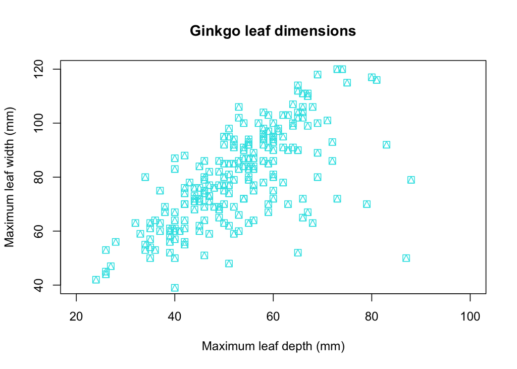

```r
scat<-plot(max_width~max_depth, data=ginkgo, pch=14, main="Ginkgo leaf dimensions", xlab="Maximum leaf depth (mm)", ylab="Maximum leaf width (mm)", xlim=c(20, 100), ylim=c(40, 120), cex=1.2, col=645)
```

```r
#structure of scatter plot is y axis ~ x axis
#label the title and axes with main=, xlab=, ylab=
#specify axes scale with xlim and ylim (don't forget you need c())
#cex is the size of the points inside the plot
#col is the color, which you can call as a number, word, or series of letters
```

### Histogram: Create a histogram of penguin flipper lengths.

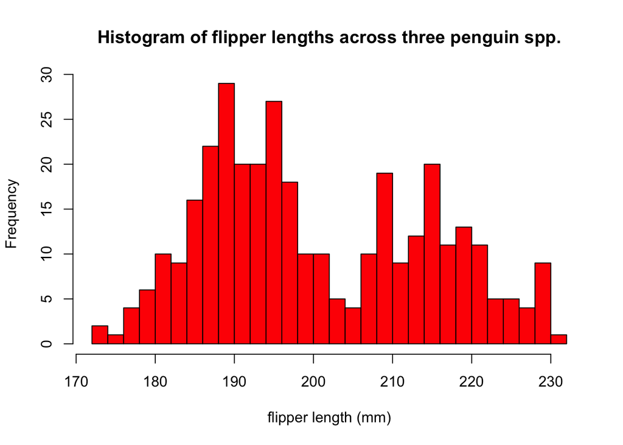

```r
hist<-hist(penguins$flipper_length_mm,main = "Histogram of flipper lengths across three penguin spp.", xlab="flipper length (mm)", breaks=30, col="red")
```

```r
#specify how many bars you want (how frequently to bin the observations) with argument breaks=
```

### Boxplot1: a simple boxplot of ginkgo petiole lengths

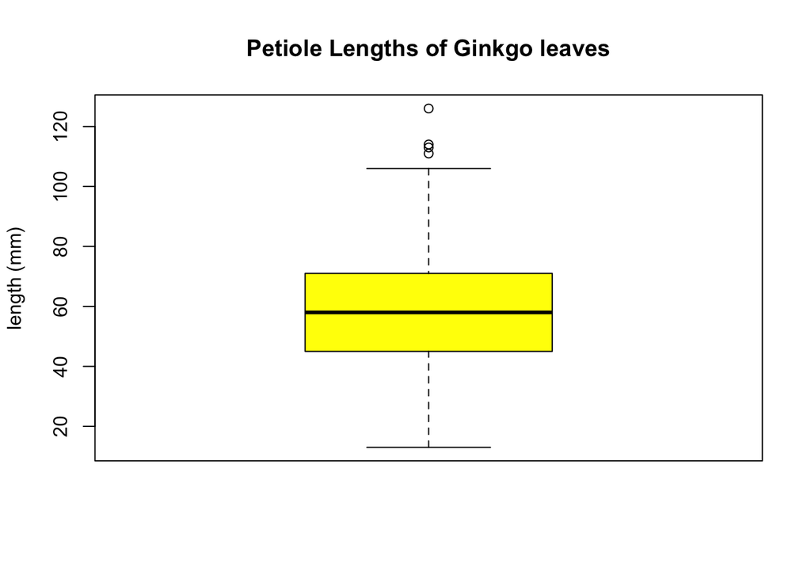

```r
box1<-boxplot(ginkgo$petiole_length, main="Petiole Lengths of Ginkgo leaves", ylab="length (mm)", col="yellow")
```

### Boxplot2:conditional boxplot of one of the continuous variables conditioned on the seeds_present column.

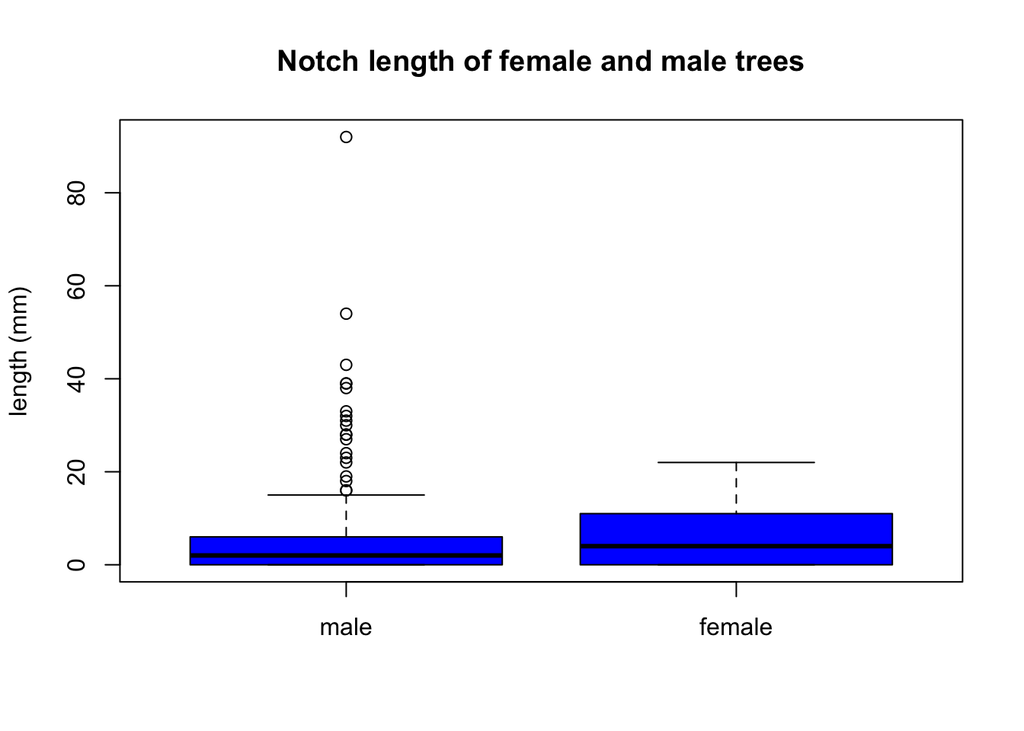

```r
box2<-boxplot(ginkgo$notch_depth~ginkgo$seeds_present, ylab="length (mm)", main="Notch length of female and male trees", names=c("male", "female"), xlab="  ", col="blue")
```

### Four Histograms

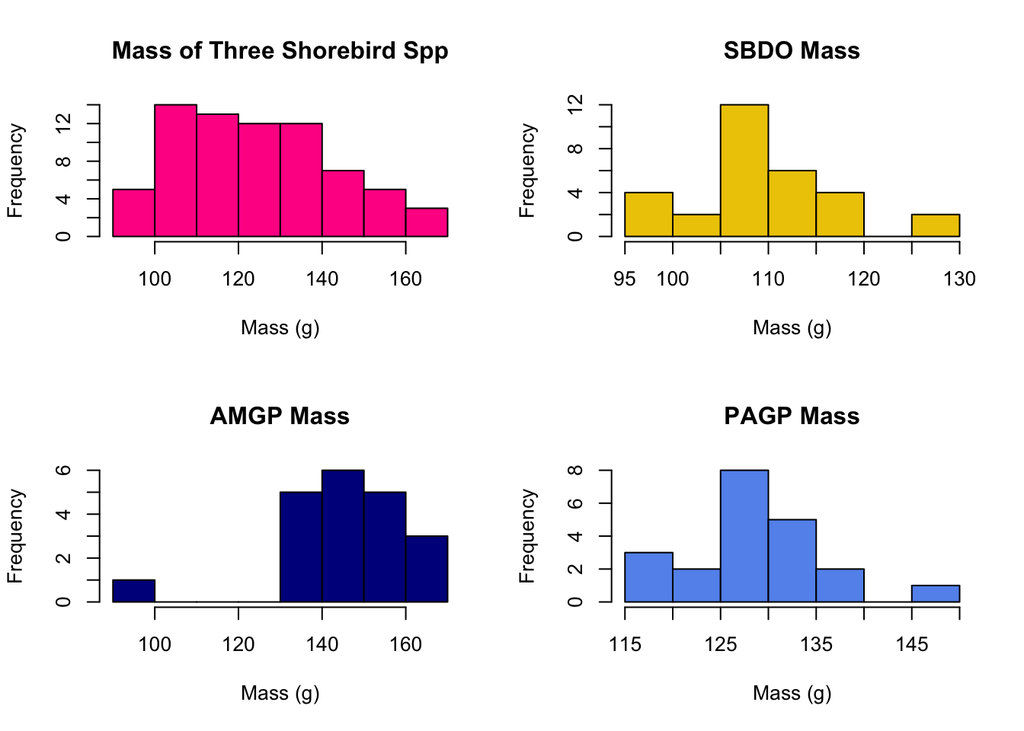

```r
shorebirds<-read.csv(here("data", "shorebirds_practice.csv"))
sbdo<-subset(shorebirds, Species=="SBDO")
amgp<-subset(shorebirds, Species=="AMGP")
pagp<-subset(shorebirds, Species=="PAGP")


par(mfrow=c(2,2))
hist(shorebirds$Mass, main="Mass of Three Shorebird Spp", xlab="Mass (g)", breaks=10, col="deeppink")
hist(sbdo$Mass, main="SBDO Mass", xlab="Mass (g)", col="gold2")
hist(amgp$Mass, main="AMGP Mass", xlab="Mass (g)", col="darkblue")
hist(pagp$Mass, main="PAGP Mass", xlab="Mass (g)", col="cornflowerblue")
```

## Distribution Functions

Using dnorm(). Dnorm is used to call the relative likelihood of a specific event for a normal distribution, in which two things are known: the mean and sd. You use it to test the likelihood of an observation, x

```r
dnorm(4, mean=9, sd=2) #in this example, the relative likelihood of observing a 4 is really low, because it would be outside 2 standard deviations
```

```
## [1] 0.00876415
```

```r
dnorm(8, mean=9, sd=2) #observing an 8 is much more likely
```

```
## [1] 0.1760327
```

Using pnorm(). Pnorm is used to calculate the cumulative density of an observation in a normal distribution, with the mean and sd known. It adds up all the likelihood of seeing the the specific event AND everything to the left of that event in the distribution.

```r
pnorm(0.5, mean=1, sd=2) #this is the probability of observing a 0.5, and everything less added together
```

```
## [1] 0.4012937
```

```r
1-pnorm(0.5, mean=1, sd=2) #this is the probability of an observation greater than 0.5. They must add up to 1
```

```
## [1] 0.5987063
```

Using qnorm(). Qnorm is used to approach likelihood from the opposite direction: given a likelihood between 0 and 1 in a normal distribution, what is the value that bounds this likelihood. Same goes for knowing the mean and sd.

```r
qnorm(0.66, mean=3, sd=1) #given we have a 66% probability, values will lie at 3.4 or below
```

```
## [1] 3.412463
```

Using dbinom(). Dbinom tests the probability of a specific event in a binomial distribution, where there is a categorical response. The two parameters we need to know are the likelihood (p) and sample size (n)

```r
dbinom(2, 6, 0.86) # Given the probability of 86%, and 6 trials, how likely are we to get exactly 2? It's pretty low!
```

```
## [1] 0.004261871
```

Using pbinom(). Similarly, pbinom tests the cumulative probability of a specific event: observing a value OR LESS.

```r
pbinom(2, size=5, prob=0.75) #Given the probability of 75% and 5 trials, how likely are we to get 2 or fewer positive events? Pretty low, because the likelihood is high
```

```
## [1] 0.1035156
```

Using qbinom(). Finally,qbinom takes the opposite approach: given a quantile, what is number of events expected?

```r
qbinom(.30, size=12, p=.25) #given 12 trials at a probability of 25%, what observation falls in the 30th quantile?
```

```
## [1] 2
```